[figure not shown]

# Welcome to Covid19 Data Analysis and Visualization

### Let's Import the modules

```python
import pandas as pd
import numpy as np
import seaborn as sns
import matplotlib.pyplot as plt
import plotly.express as px ### for plotting the data on world map
print('Modules are imported.')
```

```
Modules are imported.
```

## Task 2

### Task 2.1: importing covid19 dataset

importing "Covid19_Confirmed_dataset.csv" from "./Dataset" folder.

```python
corona_dataset_csv = pd.read_csv("Datasets/covid19_Confirmed_dataset.csv")
corona_dataset_csv.head(10)
```

|  | Province/State | Country/Region | Lat | Long | 1/22/20 | 1/23/20 | 1/24/20 | 1/25/20 | 1/26/20 | 1/27/20 | ... | 4/21/20 | 4/22/20 | 4/23/20 | 4/24/20 | 4/25/20 | 4/26/20 | 4/27/20 | 4/28/20 | 4/29/20 | 4/30/20 |
| --- | --- | --- | --- | --- | --- | --- | --- | --- | --- | --- | --- | --- | --- | --- | --- | --- | --- | --- | --- | --- | --- |
| 0 | NaN | Afghanistan | 33.0000 | 65.0000 | 0 | 0 | 0 | 0 | 0 | 0 | ... | 1092 | 1176 | 1279 | 1351 | 1463 | 1531 | 1703 | 1828 | 1939 | 2171 |
| 1 | NaN | Albania | 41.1533 | 20.1683 | 0 | 0 | 0 | 0 | 0 | 0 | ... | 609 | 634 | 663 | 678 | 712 | 726 | 736 | 750 | 766 | 773 |
| 2 | NaN | Algeria | 28.0339 | 1.6596 | 0 | 0 | 0 | 0 | 0 | 0 | ... | 2811 | 2910 | 3007 | 3127 | 3256 | 3382 | 3517 | 3649 | 3848 | 4006 |
| 3 | NaN | Andorra | 42.5063 | 1.5218 | 0 | 0 | 0 | 0 | 0 | 0 | ... | 717 | 723 | 723 | 731 | 738 | 738 | 743 | 743 | 743 | 745 |
| 4 | NaN | Angola | -11.2027 | 17.8739 | 0 | 0 | 0 | 0 | 0 | 0 | ... | 24 | 25 | 25 | 25 | 25 | 26 | 27 | 27 | 27 | 27 |
| 5 | NaN | Antigua and Barbuda | 17.0608 | -61.7964 | 0 | 0 | 0 | 0 | 0 | 0 | ... | 23 | 24 | 24 | 24 | 24 | 24 | 24 | 24 | 24 | 24 |
| 6 | NaN | Argentina | -38.4161 | -63.6167 | 0 | 0 | 0 | 0 | 0 | 0 | ... | 3031 | 3144 | 3435 | 3607 | 3780 | 3892 | 4003 | 4127 | 4285 | 4428 |
| 7 | NaN | Armenia | 40.0691 | 45.0382 | 0 | 0 | 0 | 0 | 0 | 0 | ... | 1401 | 1473 | 1523 | 1596 | 1677 | 1746 | 1808 | 1867 | 1932 | 2066 |
| 8 | Australian Capital Territory | Australia | -35.4735 | 149.0124 | 0 | 0 | 0 | 0 | 0 | 0 | ... | 104 | 104 | 104 | 105 | 106 | 106 | 106 | 106 | 106 | 106 |
| 9 | New South Wales | Australia | -33.8688 | 151.2093 | 0 | 0 | 0 | 0 | 3 | 4 | ... | 2969 | 2971 | 2976 | 2982 | 2994 | 3002 | 3004 | 3016 | 3016 | 3025 |

10 rows × 104 columns

#### Let's check the shape of the dataframe

```python
corona_dataset_csv.shape
```

```
(266, 104)
```

### Task 2.2: Delete the useless columns

```python
corona_dataset_csv.drop(["Lat", "Long"], axis = 1, inplace = True)
```

```python
corona_dataset_csv.head(10)
```

|  | Province/State | Country/Region | 1/22/20 | 1/23/20 | 1/24/20 | 1/25/20 | 1/26/20 | 1/27/20 | 1/28/20 | 1/29/20 | ... | 4/21/20 | 4/22/20 | 4/23/20 | 4/24/20 | 4/25/20 | 4/26/20 | 4/27/20 | 4/28/20 | 4/29/20 | 4/30/20 |
| --- | --- | --- | --- | --- | --- | --- | --- | --- | --- | --- | --- | --- | --- | --- | --- | --- | --- | --- | --- | --- | --- |
| 0 | NaN | Afghanistan | 0 | 0 | 0 | 0 | 0 | 0 | 0 | 0 | ... | 1092 | 1176 | 1279 | 1351 | 1463 | 1531 | 1703 | 1828 | 1939 | 2171 |
| 1 | NaN | Albania | 0 | 0 | 0 | 0 | 0 | 0 | 0 | 0 | ... | 609 | 634 | 663 | 678 | 712 | 726 | 736 | 750 | 766 | 773 |
| 2 | NaN | Algeria | 0 | 0 | 0 | 0 | 0 | 0 | 0 | 0 | ... | 2811 | 2910 | 3007 | 3127 | 3256 | 3382 | 3517 | 3649 | 3848 | 4006 |
| 3 | NaN | Andorra | 0 | 0 | 0 | 0 | 0 | 0 | 0 | 0 | ... | 717 | 723 | 723 | 731 | 738 | 738 | 743 | 743 | 743 | 745 |
| 4 | NaN | Angola | 0 | 0 | 0 | 0 | 0 | 0 | 0 | 0 | ... | 24 | 25 | 25 | 25 | 25 | 26 | 27 | 27 | 27 | 27 |
| 5 | NaN | Antigua and Barbuda | 0 | 0 | 0 | 0 | 0 | 0 | 0 | 0 | ... | 23 | 24 | 24 | 24 | 24 | 24 | 24 | 24 | 24 | 24 |
| 6 | NaN | Argentina | 0 | 0 | 0 | 0 | 0 | 0 | 0 | 0 | ... | 3031 | 3144 | 3435 | 3607 | 3780 | 3892 | 4003 | 4127 | 4285 | 4428 |
| 7 | NaN | Armenia | 0 | 0 | 0 | 0 | 0 | 0 | 0 | 0 | ... | 1401 | 1473 | 1523 | 1596 | 1677 | 1746 | 1808 | 1867 | 1932 | 2066 |
| 8 | Australian Capital Territory | Australia | 0 | 0 | 0 | 0 | 0 | 0 | 0 | 0 | ... | 104 | 104 | 104 | 105 | 106 | 106 | 106 | 106 | 106 | 106 |
| 9 | New South Wales | Australia | 0 | 0 | 0 | 0 | 3 | 4 | 4 | 4 | ... | 2969 | 2971 | 2976 | 2982 | 2994 | 3002 | 3004 | 3016 | 3016 | 3025 |

10 rows × 102 columns

### Task 2.3: Aggregating the rows by the country

```python
corona_dataset_aggregated = corona_dataset_csv.groupby("Country/Region").sum()
```

```python
corona_dataset_aggregated.head()
```

| Country/Region | 1/22/20 | 1/23/20 | 1/24/20 | 1/25/20 | 1/26/20 | 1/27/20 | 1/28/20 | 1/29/20 | 1/30/20 | 1/31/20 | ... | 4/21/20 | 4/22/20 | 4/23/20 | 4/24/20 | 4/25/20 | 4/26/20 | 4/27/20 | 4/28/20 | 4/29/20 | 4/30/20 |
| --- | --- | --- | --- | --- | --- | --- | --- | --- | --- | --- | --- | --- | --- | --- | --- | --- | --- | --- | --- | --- | --- |
| Afghanistan | 0 | 0 | 0 | 0 | 0 | 0 | 0 | 0 | 0 | 0 | ... | 1092 | 1176 | 1279 | 1351 | 1463 | 1531 | 1703 | 1828 | 1939 | 2171 |
| Albania | 0 | 0 | 0 | 0 | 0 | 0 | 0 | 0 | 0 | 0 | ... | 609 | 634 | 663 | 678 | 712 | 726 | 736 | 750 | 766 | 773 |
| Algeria | 0 | 0 | 0 | 0 | 0 | 0 | 0 | 0 | 0 | 0 | ... | 2811 | 2910 | 3007 | 3127 | 3256 | 3382 | 3517 | 3649 | 3848 | 4006 |
| Andorra | 0 | 0 | 0 | 0 | 0 | 0 | 0 | 0 | 0 | 0 | ... | 717 | 723 | 723 | 731 | 738 | 738 | 743 | 743 | 743 | 745 |
| Angola | 0 | 0 | 0 | 0 | 0 | 0 | 0 | 0 | 0 | 0 | ... | 24 | 25 | 25 | 25 | 25 | 26 | 27 | 27 | 27 | 27 |

5 rows × 100 columns

```python
corona_dataset_aggregated.shape
```

```
(187, 100)
```

### Task 2.4: Visualizing data related to a country for example China

visualization always helps for better understanding of our data.

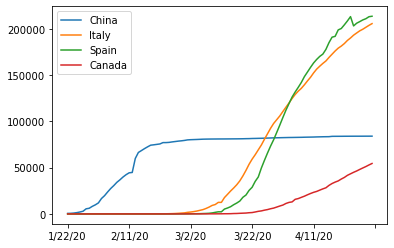

```python
corona_dataset_aggregated.loc["China"].plot()
corona_dataset_aggregated.loc["Italy"].plot()
corona_dataset_aggregated.loc["Spain"].plot()
corona_dataset_aggregated.loc["Canada"].plot()
plt.legend()
```

### Task3: Calculating a good measure

we need to find a good measure reperestend as a number, describing the spread of the virus in a country.

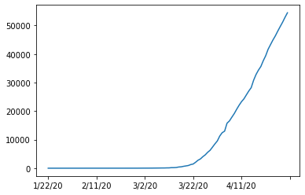

```python
corona_dataset_aggregated.loc['Canada'].plot()
```

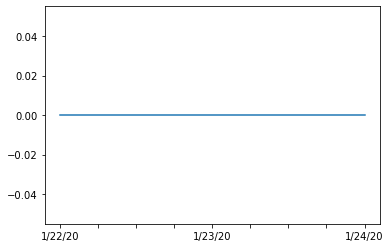

```python
corona_dataset_aggregated.loc["Canada"][:3].plot()
```

### task 3.1: caculating the first derivative of the curve

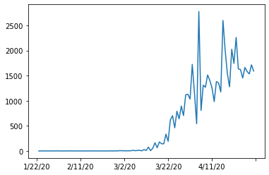

```python
corona_dataset_aggregated.loc["Canada"].diff().plot()
```

```python
corona_dataset_aggregated.loc["Canada"].diff().max()
```

```
2778.0
```

```python
corona_dataset_aggregated.loc["Canada"].diff().max()
```

```
2778.0
```

```python
corona_dataset_aggregated.loc["Spain"].diff().max()
```

```
9630.0
```

### Task 3.3: find maximum infection rate for all of the countries.

```python
countries = list(corona_dataset_aggregated.index)
max_infection_rates = []
for c in countries :
    max_infection_rates.append(corona_dataset_aggregated.loc[c].diff().max())
max_infection_rates
```

```
[232.0,
 34.0,
 199.0,
 43.0,
 5.0,
 6.0,
 291.0,
 134.0,
 497.0,
 1321.0,
 105.0,
 7.0,
 301.0,
 641.0,
 12.0,
 1485.0,
 2454.0,
 4.0,
 19.0,
 1.0,
 104.0,
 92.0,
 7.0,
 7502.0,
 26.0,
 137.0,
 41.0,
 21.0,
 6.0,
 45.0,
 31.0,
 203.0,
 2778.0,
 31.0,
 21.0,
 1138.0,
 15136.0,
 353.0,
 1.0,
 57.0,
```

[output cut: 132 more lines]

```
 5138.0,
 36188.0,
 11.0,
 578.0,
 552.0,
 8733.0,
 48.0,
 167.0,
 29.0,
 19.0,
 66.0,
 4.0,
 5.0,
 9.0,
 8.0]
```

```python
countries = list(corona_dataset_aggregated.index)
max_infection_rates = []
for c in countries :
    max_infection_rates.append(corona_dataset_aggregated.loc[c].diff().max())
corona_dataset_aggregated["max_infection_rates"] = max_infection_rates
```

```python
corona_dataset_aggregated.head()
```

| Country/Region | 1/22/20 | 1/23/20 | 1/24/20 | 1/25/20 | 1/26/20 | 1/27/20 | 1/28/20 | 1/29/20 | 1/30/20 | 1/31/20 | ... | 4/22/20 | 4/23/20 | 4/24/20 | 4/25/20 | 4/26/20 | 4/27/20 | 4/28/20 | 4/29/20 | 4/30/20 | max_infection_rates |
| --- | --- | --- | --- | --- | --- | --- | --- | --- | --- | --- | --- | --- | --- | --- | --- | --- | --- | --- | --- | --- | --- |
| Afghanistan | 0 | 0 | 0 | 0 | 0 | 0 | 0 | 0 | 0 | 0 | ... | 1176 | 1279 | 1351 | 1463 | 1531 | 1703 | 1828 | 1939 | 2171 | 232.0 |
| Albania | 0 | 0 | 0 | 0 | 0 | 0 | 0 | 0 | 0 | 0 | ... | 634 | 663 | 678 | 712 | 726 | 736 | 750 | 766 | 773 | 34.0 |
| Algeria | 0 | 0 | 0 | 0 | 0 | 0 | 0 | 0 | 0 | 0 | ... | 2910 | 3007 | 3127 | 3256 | 3382 | 3517 | 3649 | 3848 | 4006 | 199.0 |
| Andorra | 0 | 0 | 0 | 0 | 0 | 0 | 0 | 0 | 0 | 0 | ... | 723 | 723 | 731 | 738 | 738 | 743 | 743 | 743 | 745 | 43.0 |
| Angola | 0 | 0 | 0 | 0 | 0 | 0 | 0 | 0 | 0 | 0 | ... | 25 | 25 | 25 | 25 | 26 | 27 | 27 | 27 | 27 | 5.0 |

5 rows × 101 columns

### Task 3.4: create a new dataframe with only needed column

```python
corona_data = pd.DataFrame(corona_dataset_aggregated["max_infection_rates"])
```

```python
corona_data.head()
```

| Country/Region | max_infection_rates |
| --- | --- |
| Afghanistan | 232.0 |
| Albania | 34.0 |
| Algeria | 199.0 |
| Andorra | 43.0 |
| Angola | 5.0 |

### Task4:

- Importing the WorldHappinessReport.csv dataset
- selecting needed columns for our analysis
- join the datasets
- calculate the correlations as the result of our analysis

### Task 4.1 : importing the dataset

```python
happiness_report_csv = pd.read_csv("Datasets/worldwide_happiness_report.csv")
```

```python
happiness_report_csv.head()
```

|  | Overall rank | Country or region | Score | GDP per capita | Social support | Healthy life expectancy | Freedom to make life choices | Generosity | Perceptions of corruption |
| --- | --- | --- | --- | --- | --- | --- | --- | --- | --- |
| 0 | 1 | Finland | 7.769 | 1.340 | 1.587 | 0.986 | 0.596 | 0.153 | 0.393 |
| 1 | 2 | Denmark | 7.600 | 1.383 | 1.573 | 0.996 | 0.592 | 0.252 | 0.410 |
| 2 | 3 | Norway | 7.554 | 1.488 | 1.582 | 1.028 | 0.603 | 0.271 | 0.341 |
| 3 | 4 | Iceland | 7.494 | 1.380 | 1.624 | 1.026 | 0.591 | 0.354 | 0.118 |
| 4 | 5 | Netherlands | 7.488 | 1.396 | 1.522 | 0.999 | 0.557 | 0.322 | 0.298 |

### Task 4.2: let's drop the useless columns

```python
useless_cols = ["Overall rank", "Score", "Generosity", "Perceptions of corruption"]
```

```python
happiness_report_csv.drop(useless_cols, axis = 1, inplace = True)
happiness_report_csv.head()
```

|  | Country or region | GDP per capita | Social support | Healthy life expectancy | Freedom to make life choices |
| --- | --- | --- | --- | --- | --- |
| 0 | Finland | 1.340 | 1.587 | 0.986 | 0.596 |
| 1 | Denmark | 1.383 | 1.573 | 0.996 | 0.592 |
| 2 | Norway | 1.488 | 1.582 | 1.028 | 0.603 |
| 3 | Iceland | 1.380 | 1.624 | 1.026 | 0.591 |
| 4 | Netherlands | 1.396 | 1.522 | 0.999 | 0.557 |

### Task 4.3: changing the indices of the dataframe

```python
# put the name  of the countries as the index
happiness_report_csv.set_index("Country or region", inplace = True)
```

```python
happiness_report_csv.head()
```

| Country or region | GDP per capita | Social support | Healthy life expectancy | Freedom to make life choices |
| --- | --- | --- | --- | --- |
| Finland | 1.340 | 1.587 | 0.986 | 0.596 |
| Denmark | 1.383 | 1.573 | 0.996 | 0.592 |
| Norway | 1.488 | 1.582 | 1.028 | 0.603 |
| Iceland | 1.380 | 1.624 | 1.026 | 0.591 |
| Netherlands | 1.396 | 1.522 | 0.999 | 0.557 |

### Task4.4: now let's join two dataset we have prepared

#### Corona Dataset :

```python
corona_data.head()
```

| Country/Region | max_infection_rates |
| --- | --- |
| Afghanistan | 232.0 |
| Albania | 34.0 |
| Algeria | 199.0 |
| Andorra | 43.0 |
| Angola | 5.0 |

```python
corona_data.shape
```

```
(187, 1)
```

#### wolrd happiness report Dataset :

```python
happiness_report_csv.head()
```

| Country or region | GDP per capita | Social support | Healthy life expectancy | Freedom to make life choices |
| --- | --- | --- | --- | --- |
| Finland | 1.340 | 1.587 | 0.986 | 0.596 |
| Denmark | 1.383 | 1.573 | 0.996 | 0.592 |
| Norway | 1.488 | 1.582 | 1.028 | 0.603 |
| Iceland | 1.380 | 1.624 | 1.026 | 0.591 |
| Netherlands | 1.396 | 1.522 | 0.999 | 0.557 |

```python
happiness_report_csv.shape
```

```
(156, 4)
```

```python
#we need to used inner joing
data = corona_data.join(happiness_report_csv, how ="inner")
data.head()
```

|  | max_infection_rates | GDP per capita | Social support | Healthy life expectancy | Freedom to make life choices |
| --- | --- | --- | --- | --- | --- |
| Afghanistan | 232.0 | 0.350 | 0.517 | 0.361 | 0.000 |
| Albania | 34.0 | 0.947 | 0.848 | 0.874 | 0.383 |
| Algeria | 199.0 | 1.002 | 1.160 | 0.785 | 0.086 |
| Argentina | 291.0 | 1.092 | 1.432 | 0.881 | 0.471 |
| Armenia | 134.0 | 0.850 | 1.055 | 0.815 | 0.283 |

### Task 4.5: correlation matrix

```python
#see the correlation between the diffferent columns
data.corr()
```

|  | max_infection_rates | GDP per capita | Social support | Healthy life expectancy | Freedom to make life choices |
| --- | --- | --- | --- | --- | --- |
| max_infection_rates | 1.000000 | 0.250118 | 0.191958 | 0.289263 | 0.078196 |
| GDP per capita | 0.250118 | 1.000000 | 0.759468 | 0.863062 | 0.394603 |
| Social support | 0.191958 | 0.759468 | 1.000000 | 0.765286 | 0.456246 |
| Healthy life expectancy | 0.289263 | 0.863062 | 0.765286 | 1.000000 | 0.427892 |
| Freedom to make life choices | 0.078196 | 0.394603 | 0.456246 | 0.427892 | 1.000000 |

The higher the correlation values, the higher the correlation between those two columns. We can see the factors that correspond to maximum infection rate.

### Task 5: Visualization of the results

our Analysis is not finished unless we visualize the results in terms figures and graphs so that everyone can understand what you get out of our analysis

```python
data.head()
```

|  | max_infection_rates | GDP per capita | Social support | Healthy life expectancy | Freedom to make life choices |
| --- | --- | --- | --- | --- | --- |
| Afghanistan | 232.0 | 0.350 | 0.517 | 0.361 | 0.000 |
| Albania | 34.0 | 0.947 | 0.848 | 0.874 | 0.383 |
| Algeria | 199.0 | 1.002 | 1.160 | 0.785 | 0.086 |
| Argentina | 291.0 | 1.092 | 1.432 | 0.881 | 0.471 |
| Armenia | 134.0 | 0.850 | 1.055 | 0.815 | 0.283 |

### Task 5.1: Plotting GDP vs maximum Infection rate

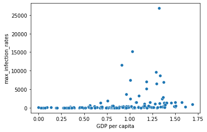

```python
x = data["GDP per capita"]
y = data["max_infection_rates"]
sns.scatterplot(x=x,y=y)
```

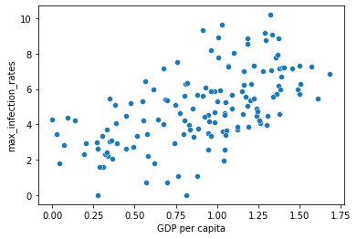

```python
x = data["GDP per capita"]
y = data["max_infection_rates"]
sns.scatterplot(x=x,y=np.log(y))
```

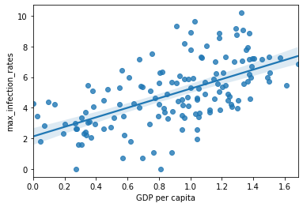

```python
sns.regplot(x=x, y=np.log(y))
```

### Task 5.2: Plotting Social support vs maximum Infection rate

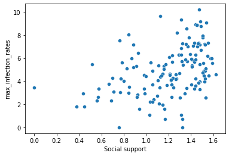

```python
x = data["Social support"]
y = data["max_infection_rates"]
sns.scatterplot(x=x,y=np.log(y))
```

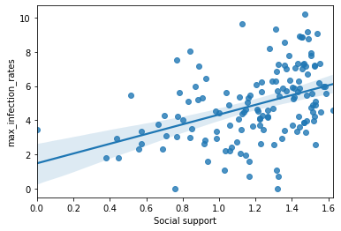

```python
sns.regplot(x=x, y=np.log(y))
```

### Task 5.3: Plotting Healthy life expectancy vs maximum Infection rate

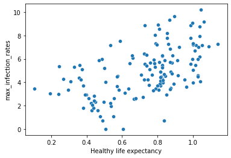

```python
x = data["Healthy life expectancy"]
y = data["max_infection_rates"]
sns.scatterplot(x=x,y=np.log(y))
```

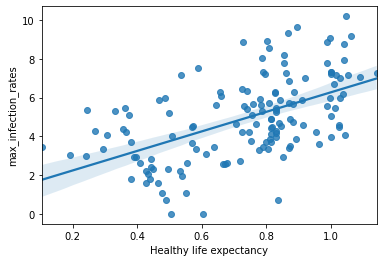

```python
sns.regplot(x=x, y=np.log(y))
```

### Task 5.4: Plotting Freedom to make life choices vs maximum Infection rate

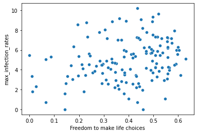

```python
x = data['Freedom to make life choices']
y = data['max_infection_rates']
sns.scatterplot(x=x,y=np.log(y))
```

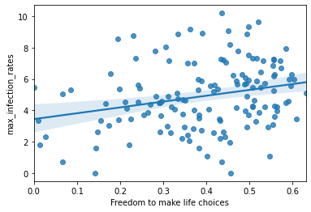

```python
sns.regplot(x=x,y=np.log(y))
```

# Visualizing Daily Covid 19 Report using May 25 and November 8, 2020 Dataset

These visualizations are based on data as of May 25, and November 8, 2020. I have used the daily report data published by John Hopkins University for May 25, 2020. The next part of the code deals with loading the .csv data to our project.

```python
#load data
df = pd.read_csv("Datasets/05-25-2020.csv")
df.info()
df.head()
```

```
<class 'pandas.core.frame.DataFrame'>
RangeIndex: 3410 entries, 0 to 3409
Data columns (total 12 columns):
 #   Column          Non-Null Count  Dtype
---  ------          --------------  -----
 0   FIPS            3006 non-null   float64
 1   Admin2          3009 non-null   object
 2   Province_State  3232 non-null   object
 3   Country_Region  3410 non-null   object
 4   Last_Update     3410 non-null   object
 5   Lat             3341 non-null   float64
 6   Long_           3341 non-null   float64
 7   Confirmed       3410 non-null   int64
 8   Deaths          3410 non-null   int64
 9   Recovered       3410 non-null   int64
 10  Active          3410 non-null   int64
 11  Combined_Key    3410 non-null   object
dtypes: float64(3), int64(4), object(5)
memory usage: 319.8+ KB
```

|  | FIPS | Admin2 | Province_State | Country_Region | Last_Update | Lat | Long_ | Confirmed | Deaths | Recovered | Active | Combined_Key |
| --- | --- | --- | --- | --- | --- | --- | --- | --- | --- | --- | --- | --- |
| 0 | 45001.0 | Abbeville | South Carolina | US | 2020-05-26 02:32:35 | 34.223334 | -82.461707 | 35 | 0 | 0 | 35 | Abbeville, South Carolina, US |
| 1 | 22001.0 | Acadia | Louisiana | US | 2020-05-26 02:32:35 | 30.295065 | -92.414197 | 299 | 18 | 0 | 281 | Acadia, Louisiana, US |
| 2 | 51001.0 | Accomack | Virginia | US | 2020-05-26 02:32:35 | 37.767072 | -75.632346 | 731 | 11 | 0 | 720 | Accomack, Virginia, US |
| 3 | 16001.0 | Ada | Idaho | US | 2020-05-26 02:32:35 | 43.452658 | -116.241552 | 796 | 23 | 0 | 773 | Ada, Idaho, US |
| 4 | 19001.0 | Adair | Iowa | US | 2020-05-26 02:32:35 | 41.330756 | -94.471059 | 8 | 0 | 0 | 8 | Adair, Iowa, US |

Preprocessing the data

Now since our data has loaded successfully, the next step is to preprocess the data before using it for plotting. It will include :

- Removing superfluous columns like ‘FIPS’, ‘Admin2', ‘Last_Update’ (since all the data is for single-day — 25th May).
- Removing columns ‘Province_State’ and ‘Combined_Key’ since statewide data is not available for all the countries
- Grouping together data by ‘Country_Region’ and rename the column to ‘Country’

```python
df.drop(['FIPS', 'Admin2','Last_Update','Province_State', 'Combined_Key'], axis=1, inplace=True)
df.rename(columns={'Country_Region': "Country"}, inplace=True)
df.head()
```

|  | Country | Lat | Long_ | Confirmed | Deaths | Recovered | Active |
| --- | --- | --- | --- | --- | --- | --- | --- |
| 0 | US | 34.223334 | -82.461707 | 35 | 0 | 0 | 35 |
| 1 | US | 30.295065 | -92.414197 | 299 | 18 | 0 | 281 |
| 2 | US | 37.767072 | -75.632346 | 731 | 11 | 0 | 720 |
| 3 | US | 43.452658 | -116.241552 | 796 | 23 | 0 | 773 |
| 4 | US | 41.330756 | -94.471059 | 8 | 0 | 0 | 8 |

The data can be grouped together by the ‘groupby’ function of the dataframe. It is similar to the GROUPBY statement in SQL.

```python
### group the data by country

world = df.groupby("Country")['Confirmed','Active','Recovered','Deaths'].sum().reset_index()
world.head()
```

|  | Country | Confirmed | Active | Recovered | Deaths |
| --- | --- | --- | --- | --- | --- |
| 0 | Afghanistan | 11173 | 9857 | 1097 | 219 |
| 1 | Albania | 1004 | 177 | 795 | 32 |
| 2 | Algeria | 8503 | 3147 | 4747 | 609 |
| 3 | Andorra | 763 | 49 | 663 | 51 |
| 4 | Angola | 70 | 48 | 18 | 4 |

Plotting the top 20 countries with the maximum number of confirmed cases

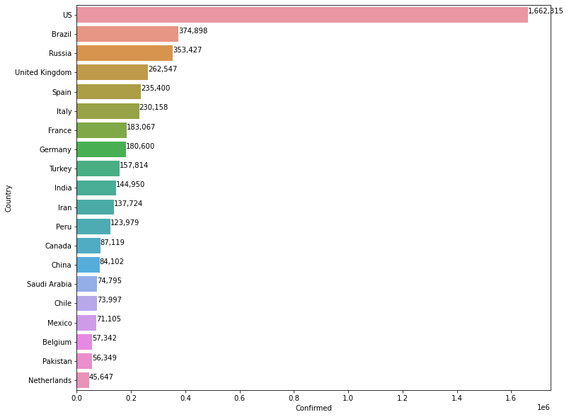

```python
### Find top 20 countries with maximum number of confirmed cases
top_20 = world.sort_values(by=['Confirmed'], ascending=False).head(20)
### Generate a Barplot
plt.figure(figsize=(12,10))
plot = sns.barplot(top_20['Confirmed'], top_20['Country'])
for i,(value,name) in enumerate(zip(top_20['Confirmed'],top_20['Country'])):
  plot.text(value,i-0.05,f'{value:,.0f}',size=10)
plt.show()
```

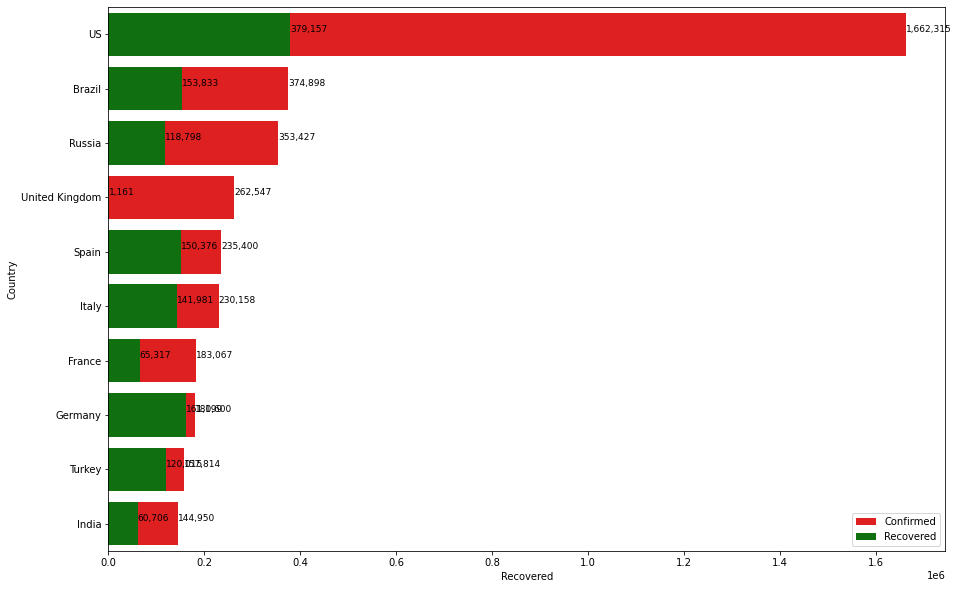

```python
top_10 = world.sort_values(by=['Confirmed'], ascending=False).head(10)

### Generate a Barplot
plt.figure(figsize=(15,10))
confirmed = sns.barplot(top_10['Confirmed'], top_10['Country'], color = 'red', label='Confirmed')
recovered = sns.barplot(top_10['Recovered'], top_10['Country'], color = 'green', label='Recovered')

### Adding Texts for barplots
for i,(value,name) in enumerate(zip(top_10['Confirmed'],top_10['Country'])):
  confirmed.text(value,i-0.05,f'{value:,.0f}',size=9)
for i,(value,name) in enumerate(zip(top_10['Recovered'],top_10['Country'])):
  recovered.text(value,i-0.05,f'{value:,.0f}',size=9)
plt.legend(loc=4)
plt.show()
```

Plotting a Choropleth map on World Map

- A choropleth map is a type of thematic map in which areas are shaded or patterned in proportion to a statistical variable that represents an aggregate summary of a geographic characteristic within each area, such as population density or per-capita income.
- Choropleth maps provide an easy way to visualize how a measurement varies across a geographic area or show the level of variability within a region

```python
figure = px.choropleth(world,locations='Country', locationmode='country names', color='Confirmed', hover_name='Country', color_continuous_scale='tealgrn', range_color=[1,1000000],title='Countries with Confirmed cases')
figure.show()
```

[interactive chart not shown]

## As of November 8, 2020

```python
#Read data
df = pd.read_csv("Datasets/11-08-2020.csv")
df.info()
df.head()
```

```
<class 'pandas.core.frame.DataFrame'>
RangeIndex: 3960 entries, 0 to 3959
Data columns (total 14 columns):
 #   Column               Non-Null Count  Dtype
---  ------               --------------  -----
 0   FIPS                 3262 non-null   float64
 1   Admin2               3267 non-null   object
 2   Province_State       3790 non-null   object
 3   Country_Region       3960 non-null   object
 4   Last_Update          3960 non-null   object
 5   Lat                  3878 non-null   float64
 6   Long_                3878 non-null   float64
 7   Confirmed            3960 non-null   int64
 8   Deaths               3960 non-null   int64
 9   Recovered            3960 non-null   int64
 10  Active               3958 non-null   float64
 11  Combined_Key         3960 non-null   object
 12  Incidence_Rate       3878 non-null   float64
 13  Case-Fatality_Ratio  3917 non-null   float64
dtypes: float64(6), int64(3), object(5)
memory usage: 433.2+ KB
```

|  | FIPS | Admin2 | Province_State | Country_Region | Last_Update | Lat | Long_ | Confirmed | Deaths | Recovered | Active | Combined_Key | Incidence_Rate | Case-Fatality_Ratio |
| --- | --- | --- | --- | --- | --- | --- | --- | --- | --- | --- | --- | --- | --- | --- |
| 0 | NaN | NaN | NaN | Afghanistan | 2020-11-09 05:25:45 | 33.93911 | 67.709953 | 42092 | 1558 | 34458 | 6076.0 | Afghanistan | 108.126879 | 3.701416 |
| 1 | NaN | NaN | NaN | Albania | 2020-11-09 05:25:45 | 41.15330 | 20.168300 | 24206 | 559 | 12092 | 11555.0 | Albania | 841.128640 | 2.309345 |
| 2 | NaN | NaN | NaN | Algeria | 2020-11-09 05:25:45 | 28.03390 | 1.659600 | 62051 | 2048 | 42037 | 17966.0 | Algeria | 141.504046 | 3.300511 |
| 3 | NaN | NaN | NaN | Andorra | 2020-11-09 05:25:45 | 42.50630 | 1.521800 | 5383 | 75 | 4248 | 1060.0 | Andorra | 6966.931987 | 1.393275 |
| 4 | NaN | NaN | NaN | Angola | 2020-11-09 05:25:45 | -11.20270 | 17.873900 | 12433 | 307 | 5899 | 6227.0 | Angola | 37.829059 | 2.469235 |

```python
df.drop(['FIPS', 'Admin2','Last_Update','Province_State', 'Combined_Key'], axis=1, inplace=True)
df.rename(columns={'Country_Region': "Country"}, inplace=True)
df.head()
```

|  | Country | Lat | Long_ | Confirmed | Deaths | Recovered | Active | Incidence_Rate | Case-Fatality_Ratio |
| --- | --- | --- | --- | --- | --- | --- | --- | --- | --- |
| 0 | Afghanistan | 33.93911 | 67.709953 | 42092 | 1558 | 34458 | 6076.0 | 108.126879 | 3.701416 |
| 1 | Albania | 41.15330 | 20.168300 | 24206 | 559 | 12092 | 11555.0 | 841.128640 | 2.309345 |
| 2 | Algeria | 28.03390 | 1.659600 | 62051 | 2048 | 42037 | 17966.0 | 141.504046 | 3.300511 |
| 3 | Andorra | 42.50630 | 1.521800 | 5383 | 75 | 4248 | 1060.0 | 6966.931987 | 1.393275 |
| 4 | Angola | -11.20270 | 17.873900 | 12433 | 307 | 5899 | 6227.0 | 37.829059 | 2.469235 |

```python
### group the data by country

world = df.groupby("Country")['Confirmed','Active','Recovered','Deaths'].sum().reset_index()
world.head()
```

|  | Country | Confirmed | Active | Recovered | Deaths |
| --- | --- | --- | --- | --- | --- |
| 0 | Afghanistan | 42092 | 6076.0 | 34458 | 1558 |
| 1 | Albania | 24206 | 11555.0 | 12092 | 559 |
| 2 | Algeria | 62051 | 17966.0 | 42037 | 2048 |
| 3 | Andorra | 5383 | 1060.0 | 4248 | 75 |
| 4 | Angola | 12433 | 6227.0 | 5899 | 307 |

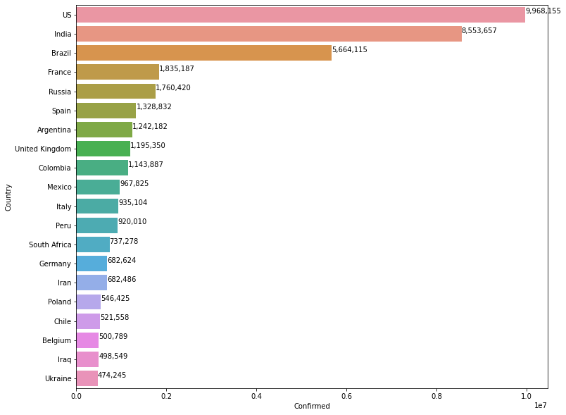

```python
### Find top 20 countries with maximum number of confirmed cases
top_20 = world.sort_values(by=['Confirmed'], ascending=False).head(20)
### Generate a Barplot
plt.figure(figsize=(12,10))
plot = sns.barplot(top_20['Confirmed'], top_20['Country'])
for i,(value,name) in enumerate(zip(top_20['Confirmed'],top_20['Country'])):
  plot.text(value,i-0.05,f'{value:,.0f}',size=10)
plt.show()
```

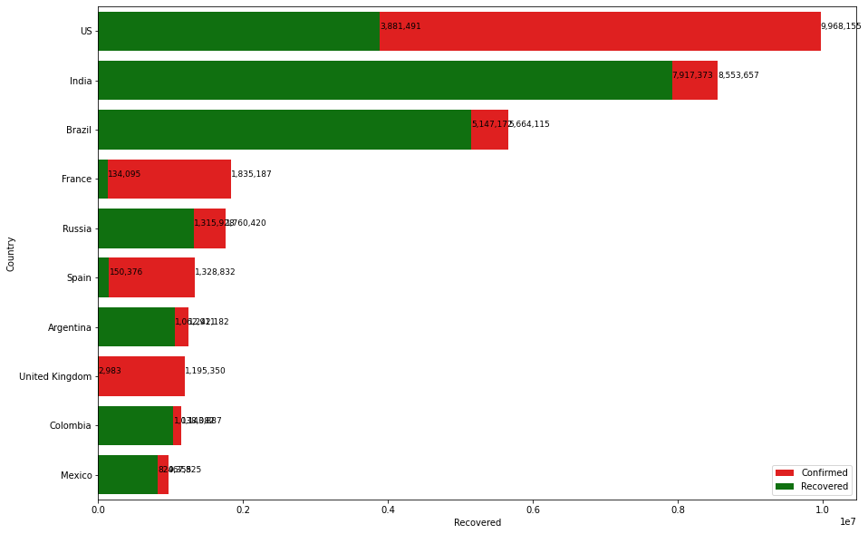

```python
top_10 = world.sort_values(by=['Confirmed'], ascending=False).head(10)

### Generate a Barplot
plt.figure(figsize=(15,10))
confirmed = sns.barplot(top_10['Confirmed'], top_10['Country'], color = 'red', label='Confirmed')
recovered = sns.barplot(top_10['Recovered'], top_10['Country'], color = 'green', label='Recovered')

### Adding Texts for barplots
for i,(value,name) in enumerate(zip(top_10['Confirmed'],top_10['Country'])):
  confirmed.text(value,i-0.05,f'{value:,.0f}',size=9)
for i,(value,name) in enumerate(zip(top_10['Recovered'],top_10['Country'])):
  recovered.text(value,i-0.05,f'{value:,.0f}',size=9)
plt.legend(loc=4)
plt.show()
```

```python
figure = px.choropleth(world,locations='Country', locationmode='country names', color='Confirmed', hover_name='Country', color_continuous_scale='tealgrn', range_color=[1,1000000],title='Countries with Confirmed cases')
figure.show()
```

[interactive chart not shown]

```python
figure = px.choropleth(world,locations='Country', locationmode='country names', color='Deaths',
                       hover_name='Country', color_continuous_scale='tealgrn', range_color=[1,1000000],title='Countries with Death cases')
figure.show()
```

[interactive chart not shown]

```python
figure = px.choropleth(world,locations='Country', locationmode='country names', color='Recovered', hover_name='Country', color_continuous_scale='tealgrn', range_color=[1,1000000],title='Countries with Recovered cases')
figure.show()
```

[interactive chart not shown]

[corona datase](https://github.com/imdevskp/covid_19_jhu_data_web_scrap_and_cleaning)

[datasets](https://github.com/CSSEGISandData/COVID-19/tree/master/csse_covid_19_data/csse_covid_19_daily_reports)

# Cases Over Time

```python
full_grouped = pd.read_csv('Datasets/full_grouped.csv')
full_grouped['Date'] = pd.to_datetime(full_grouped['Date'])
full_grouped.head()
```

|  | Date | Country/Region | Confirmed | Deaths | Recovered | Active | New cases | New deaths | New recovered | WHO Region |
| --- | --- | --- | --- | --- | --- | --- | --- | --- | --- | --- |
| 0 | 2020-01-22 | Afghanistan | 0 | 0 | 0 | 0 | 0 | 0 | 0 | Eastern Mediterranean |
| 1 | 2020-01-22 | Albania | 0 | 0 | 0 | 0 | 0 | 0 | 0 | Europe |
| 2 | 2020-01-22 | Algeria | 0 | 0 | 0 | 0 | 0 | 0 | 0 | Africa |
| 3 | 2020-01-22 | Andorra | 0 | 0 | 0 | 0 | 0 | 0 | 0 | Europe |
| 4 | 2020-01-22 | Angola | 0 | 0 | 0 | 0 | 0 | 0 | 0 | Africa |

```python
full_grouped.shape
```

```
(35156, 10)
```

```python
# Over the time

fig = px.choropleth(full_grouped, locations="Country/Region",
                    color=np.log(full_grouped["Confirmed"]),
                    locationmode='country names', hover_name="Country/Region",
                    animation_frame=full_grouped["Date"].dt.strftime('%Y-%m-%d'),
                    title='Cases over time', color_continuous_scale=px.colors.sequential.matter)
fig.update(layout_coloraxis_showscale=False)
fig.show()
```

[interactive chart not shown]

## Cases over the time

```python
# color pallette
cnf, dth, rec, act = '#393e46', '#ff2e63', '#21bf73', '#fe9801'
```

```python
temp = full_grouped.groupby('Date')['Recovered', 'Deaths', 'Active'].sum().reset_index()
temp = temp.melt(id_vars="Date", value_vars=['Recovered', 'Deaths', 'Active'],var_name='Case', value_name='Count')
temp.head()

fig = px.area(temp, x="Date", y="Count", color='Case', height=600, width=700,title='Cases over time', color_discrete_sequence = [rec, dth, act])
fig.update_layout(xaxis_rangeslider_visible=True)

fig.show()
```

[interactive chart not shown]

```python
def plot_stacked(col):
    fig = px.bar(full_grouped, x="Date", y=col, color='Country/Region',
                 height=600, title=col,
                 color_discrete_sequence = px.colors.cyclical.mygbm)
    fig.update_layout(showlegend=True)
    fig.show()
```

```python
def plot_line(col):
    fig = px.line(full_grouped, x="Date", y=col, color='Country/Region',
                  height=600, title=col,color_discrete_sequence = px.colors.cyclical.mygbm)
    fig.update_layout(showlegend=True)
    fig.show()
```

```python
plot_stacked('Confirmed')
```

[interactive chart not shown]

```python
plot_stacked('Deaths')
```

[interactive chart not shown]

```python
plot_stacked('New cases')
```

[interactive chart not shown]

```python
plot_stacked('Active')
```

[interactive chart not shown]

```python
plot_line('Confirmed')
```

[interactive chart not shown]

```python
plot_line('Deaths')
```

[interactive chart not shown]

```python
plot_line('New cases')
```

[interactive chart not shown]

```python
plot_line('Active')
```

[interactive chart not shown]

```python
"""
def gt_n(n):
    countries = full_grouped[full_grouped['Confirmed']>n]['Country/Region'].unique()
    temp = full_table[full_table['Country/Region'].isin(countries)]
    temp = temp.groupby(['Country/Region', 'Date'])['Confirmed'].sum().reset_index()
    temp = temp[temp['Confirmed']>n]
    # print(temp.head())
    min_date = temp.groupby('Country/Region')['Date'].min().reset_index()
    min_date.columns = ['Country/Region', 'Min Date']
    # print(min_date.head())
    from_nth_case = pd.merge(temp, min_date, on='Country/Region')
    from_nth_case['Date'] = pd.to_datetime(from_nth_case['Date'])
    from_nth_case['Min Date'] = pd.to_datetime(from_nth_case['Min Date'])
    from_nth_case['N days'] = (from_nth_case['Date'] - from_nth_case['MinDate']).dt.days
    # print(from_nth_case.head())
    fig = px.line(from_nth_case, x='N days', y='Confirmed', color='Country/Region',
                  title='N days from '+str(n)+' case', height=600)
    fig.show()
"""
```

[output not shown]

```python
#gt_n(100000)
```

## Bubble Plot

```python
def plot_bubble(col, pal):
    temp = full_grouped[full_grouped[col]>0].sort_values('Country/Region',ascending=False)
    fig = px.scatter(temp, x='Date', y='Country/Region', size=col, color=col,height=3000,
                     color_continuous_scale=pal)
    fig.update_layout(yaxis = dict(dtick = 1))
    fig.update(layout_coloraxis_showscale=False)
    fig.show()
```

```python
plot_bubble('New cases', 'Viridis')
```

[interactive chart not shown]

```python
plot_bubble('Active', 'Viridis')
```

[interactive chart not shown]

## Epidemic Span

```python
temp = full_grouped[['Date', 'Country/Region', 'New cases']]
temp['New cases reported ?'] = temp['New cases']!=0
temp['New cases reported ?'] = temp['New cases reported ?'].astype(int)
# temp.head()
```

```python
import plotly.graph_objs as go
```

```python
fig = go.Figure(data=go.Heatmap(
    z=temp['New cases reported ?'],
    x=temp['Date'],
    y=temp['Country/Region'],
    colorscale='Emrld',
    showlegend=False,
    text=temp['New cases reported ?']))
fig.update_layout(yaxis = dict(dtick = 1))
fig.update_layout(height=3000)
fig.show()
```

[interactive chart not shown]

## Weekly Statistics

```python
full_grouped['Week No.'] = full_grouped['Date'].dt.strftime('%U')
week_wise = full_grouped.groupby('Week No.')['Confirmed', 'Deaths',
                                             'Recovered', 'Active', 'New cases',
                                             'New deaths', 'New recovered'].sum().reset_index()
```

```python
def plot_weekwise(col, hue):
    fig = px.bar(week_wise, x="Week No.", y=col, width=700,color_discrete_sequence=[hue])
    fig.update_layout(title=col, xaxis_title="", yaxis_title="")
    fig.show()
```

```python
plot_weekwise('Confirmed', '#000000')
```

[interactive chart not shown]

```python
plot_weekwise('Deaths', dth)
```

[interactive chart not shown]

```python
plot_weekwise('New cases', '#cd6684')
```

[interactive chart not shown]

## Monthly statistics

```python
full_grouped['Month'] = pd.DatetimeIndex(full_grouped['Date']).month
month_wise = full_grouped.groupby('Month')['Confirmed', 'Deaths', 'Recovered',
                                           'Active', 'New cases', 'New deaths',
                                           'New recovered'].sum().reset_index()
```

```python
def plot_monthwise(col, hue):
    fig = px.bar(month_wise, x="Month", y=col, width=700,color_discrete_sequence=[hue])
    fig.update_layout(title=col, xaxis_title="", yaxis_title="")
    fig.show()
```

```python
plot_monthwise('Confirmed', '#000000')
```

[interactive chart not shown]

```python
plot_monthwise('Deaths', dth)
```

[interactive chart not shown]

```python
plot_monthwise('New cases', '#cd6684')
```

[interactive chart not shown]

## credit:

[Jaskeerat Singh Bhatia](https://towardsdatascience.com/covid-19-data-visualization-using-python-3c8bcfaeff5f)

[Devakumar Kp](https://www.kaggle.com/imdevskp/covid-19-analysis-visualization-comparisons)